# Diseño y Análisis de Experimentos

Diseño Factorial

Sebastian Ariza y Yanina lopez[^1]

Marzo 1, 2022

## Análisis del Experimento

### Lectura de datos

```r
datos <- read.table("C:/Users/JHON G. BOTELLO/OneDrive - Universidad del Norte/Escritorio/DATOS.txt",header = TRUE)


## convert 'A' and 'B' to factors
datos$A <- as.factor(datos$A)
datos$B <- as.factor(datos$B)

datos$C <- as.numeric(datos$C)

datos <- na.omit(datos)

summary(datos)
```

```
##    A       B            C
##  DT :48   NO:96   Min.   :0.1512
##  KNN:48   SI:96   1st Qu.:0.3795
##  LR :48           Median :0.5270
##  RF :48           Mean   :0.5550
##                   3rd Qu.:0.6594
##                   Max.   :1.0850
```

El número de réplicas puede obtenerse haciendo:

```r
## replicates per combination
with(datos, tapply(C, list(A, B), length))
```

```
##     NO SI
## DT  24 24
## KNN 24 24
## LR  24 24
## RF  24 24
```

El número total de unidades experimentales es

```r
## how many runs?
NROW(datos)
```

```
## [1] 192
```

Como se discutió anteriormente, una vez leídos los datos procedemos a visualizarlos:

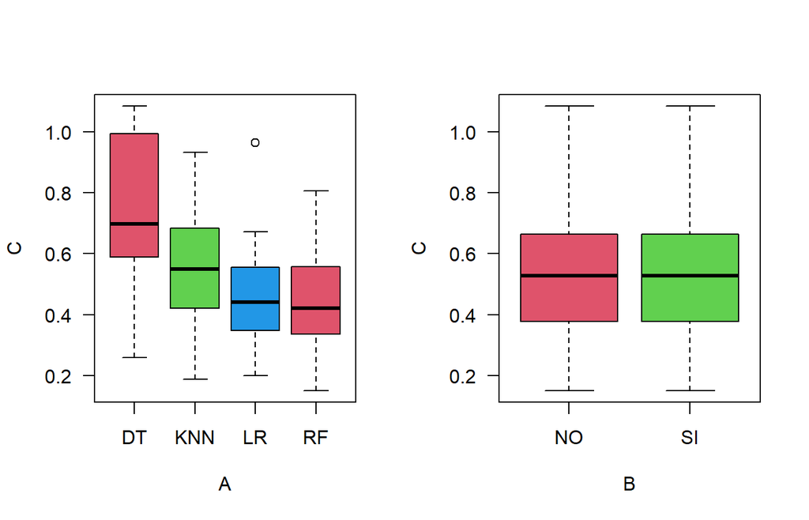

```r
## boxplots for main effects
par(mfrow = c(1, 2))
boxplot(C ~ A, data = datos, las = 1, col = 2:4,
        xlab = 'A', ylab = 'C')

boxplot(C ~ B, data = datos, las = 1, col = 2:4,
        xlab = 'B', ylab = 'C')
```

La otra posibilidad es evaluar la existencia de posibles efectos de interacción entre `A` y `B`:

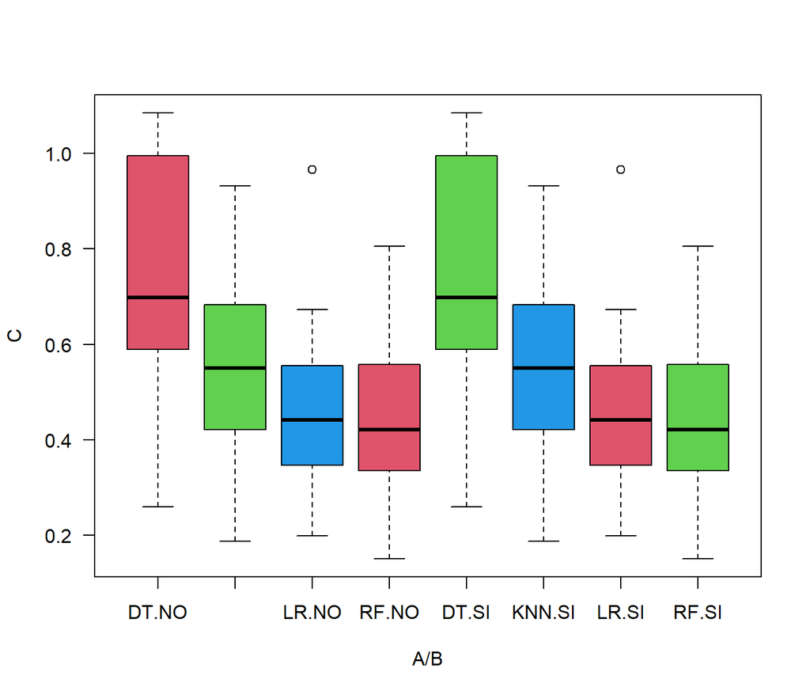

```r
## boxplot for interactions
par(mfrow = c(1, 1))
boxplot(C ~ A*B,
        data = datos, las = 1, col = 2:4,
        xlab = 'A/B', ylab = 'C')
```

Este mismo gráfico de interacción puede hacerse analizando los perfiles de la variable respuesta `C` dependiendo de los niveles de `A` y `B`:

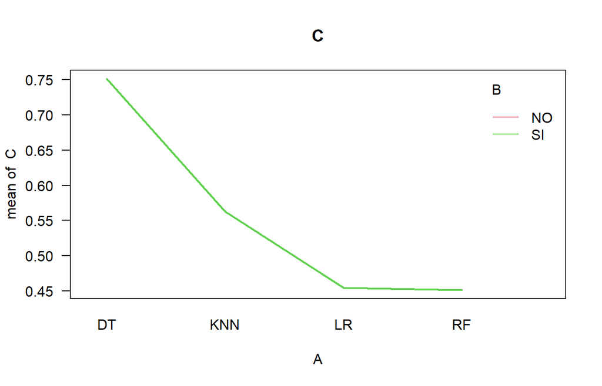

```r
## fixing temperature
with(datos,
    interaction.plot(A, B, C,
                     las = 1,
                     lty = 1,
                     lwd = 2,
                     col = 2:4,
                     main = "C"))
```

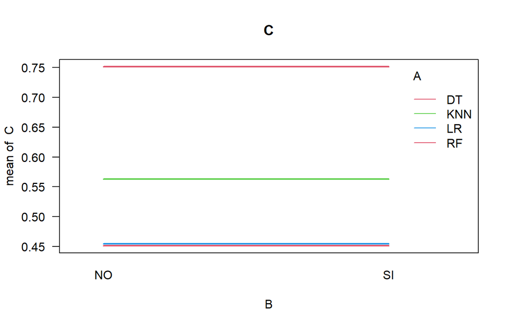

```r
## same fixing material
with(datos,
     interaction.plot(B, A, C,
                      las = 1,
                      lty = 1,
                      lwd = 2,
                      col = 2:4,
                      main = "C"))
```

Ahora, procedamos a calcular algunas medidas de tendencia central, posición y dispersión:

```r
##  summary statistics
with(datos, tapply(C, list(A, B), mean))
```

```
##            NO        SI
## DT  0.7515015 0.7515015
## KNN 0.5629257 0.5629257
## LR  0.4542511 0.4542511
## RF  0.4513396 0.4513396
```

```r
with(datos, tapply(C, list(A, B), sd))
```

```
##            NO        SI
## DT  0.2257743 0.2257743
## KNN 0.1986528 0.1986528
## LR  0.1670858 0.1670858
## RF  0.1620991 0.1620991
```

### Construcciión de la tabla ANOVA

Ahora construimos la tabla ANOVA *incluyendo* el término de interacción:

```r
## ANOVA with interaction
fit_interaction <- aov(C ~ A*B, data = datos)
anova(fit_interaction)
```

```
## Analysis of Variance Table
##
## Response: C
##            Df Sum Sq Mean Sq F value    Pr(>F)
## A           3 2.8594 0.95314  26.361 3.128e-14 ***
## B           1 0.0000 0.00000   0.000         1
## A:B         3 0.0000 0.00000   0.000         1
## Residuals 184 6.6530 0.03616
## ---
## Signif. codes:  0 '***' 0.001 '**' 0.01 '*' 0.05 '.' 0.1 ' ' 1
```

La conclusión de este primer modelo es que la interacción entre `A` y `B`, definida como `A:B` en el resultado de `anova(fit)`, es **no** significativa al 0.05%. Asi mismo el factor B no es significativo.

Puesto que la interacción y el factor B **no** son significativos, debemos remover estos términos del modelo y recalcularlo:

```r
## ANOVA with no interaction
fit_no_interaction <- aov(C ~ A, data = datos)
summary(fit_no_interaction)
```

```
##              Df Sum Sq Mean Sq F value   Pr(>F)
## A             3  2.859  0.9531   26.93 1.55e-14 ***
## Residuals   188  6.653  0.0354
## ---
## Signif. codes:  0 '***' 0.001 '**' 0.01 '*' 0.05 '.' 0.1 ' ' 1
```

La conclusión de la tabla ANOVA es que existe al menos un tipo de `A` para el que se producen resultados diferentes de la media global.

### Cuantificación del efecto

Ahora procedemos a determinar la *la magnitud del efecto* de cada nivel de `A`. Esto es posible a partir del objeto `fit`. Para ello utilizamos los estimadores de máxima verosimilitud obtenidos al emplear el método de mínimos cuadrados ordinarios en el modelo de Regresión Lineal Múltiple:

```r
## MLR for the batteries experiment
fit_lm <- lm(C ~ A, data = datos)
summary(fit_lm)
```

```
##
## Call:
## lm(formula = C ~ A, data = datos)
##
## Residuals:
##      Min       1Q   Median       3Q      Max
## -0.49150 -0.12232 -0.02057  0.11972  0.51084
##
## Coefficients:
##             Estimate Std. Error t value Pr(>|t|)
## (Intercept)  0.75150    0.02715  27.677  < 2e-16 ***
## AKNN        -0.18858    0.03840  -4.911 1.96e-06 ***
## ALR         -0.29725    0.03840  -7.741 5.90e-13 ***
## ARF         -0.30016    0.03840  -7.817 3.75e-13 ***
## ---
## Signif. codes:  0 '***' 0.001 '**' 0.01 '*' 0.05 '.' 0.1 ' ' 1
##
## Residual standard error: 0.1881 on 188 degrees of freedom
## Multiple R-squared:  0.3006, Adjusted R-squared:  0.2894
## F-statistic: 26.93 on 3 and 188 DF,  p-value: 1.546e-14
```

TUCKEY

```r
## verificamos si está disponibel el paquete "car"
if(!require(car)) install.packages('car')
require(car)

## HSD test
anova <- aov(fit_lm)
TukeyHSD(anova, "A", ordered = TRUE)
```

```
##   Tukey multiple comparisons of means
##     95% family-wise confidence level
##     factor levels have been ordered
##
## Fit: aov(formula = fit_lm)
##
## $A
##               diff          lwr       upr     p adj
## LR-RF  0.002911539 -0.096625803 0.1024489 0.9998432
## KNN-RF 0.111586159  0.012048816 0.2111235 0.0211857
## DT-RF  0.300161906  0.200624564 0.3996992 0.0000000
## KNN-LR 0.108674619  0.009137277 0.2082120 0.0263030
## DT-LR  0.297250367  0.197713025 0.3967877 0.0000000
## DT-KNN 0.188575747  0.089038405 0.2881131 0.0000116
```

```r
## compute residuals
r <- rstudent(fit_lm)
```

```r
## verify if car package is available
if(!require(car)) install.packages('car')
require(car)

## normality assumptions
shapiro.test(r)
```

```
##
##  Shapiro-Wilk normality test
##
## data:  r
## W = 0.98609, p-value = 0.05532
```

```r
## varianza constante usando Breusch-Pagan
car:::ncvTest(fit_lm)
```

```
## Non-constant Variance Score Test
## Variance formula: ~ fitted.values
## Chisquare = 7.076669, Df = 1, p = 0.0078094
```

```r
## independence using Durbin-Watson
durbinWatsonTest(fit_lm)
```

```
##  lag Autocorrelation D-W Statistic p-value
##    1       0.4739469      1.051603       0
##  Alternative hypothesis: rho != 0
```

Se inclumplen supuestos!!

[^1]: Estudiantes, Departamento de Ingeniería Industrial, Universidad del Norte, Barranquilla, Colombia.